# Notebook

```python
import numpy as np
import matplotlib.pyplot as plt
import plumed
import subprocess
import os
from contextlib import contextmanager
import re
import pandas
import pathlib
```

```python
# small utility to clean up backup files:
def clean():
    print(subprocess.run("rm -f \#*; rm -fr bck.*",shell=True))
# small utility to run with mpiexec
def run_mpi(cmd,nprocs=1):
    return subprocess.run("mpiexec -np {} --oversubscribe {}".format(nprocs,cmd),shell=True)
# change directory and execute commands
# at the end of the context (or in the event of an error),
# previous working directory is restored
@contextmanager
def cd(newdir: os.PathLike):
    prevdir = os.getcwd()
    path=os.path.expanduser(newdir)
    pathlib.Path(path).mkdir(parents=True, exist_ok=True)
    try:
        os.chdir(path)
    except FileNotFoundError:
        try:
            os.mkdir(path)
            os.chdir(path)
        except:
            FileExistsError
    try:
        yield
    finally:
        os.chdir(prevdir)
```

```python
# this is our standard input file:
!cat grompp.mdp
```

```
integrator               = md
dt                       = 0.002
nsteps                   = 500000

nstlog                   = 500
nstenergy                = 500
nstxout-compressed       = 500

continuation             = yes
constraints              = h-bonds
constraint-algorithm     = lincs

cutoff-scheme            = Verlet

coulombtype              = PME
rcoulomb                 = 1.0

vdwtype                  = Cut-off
rvdw                     = 1.0
DispCorr                 = EnerPres

tcoupl                   = V-rescale
tc-grps                  = Protein  SOL
tau-t                    = 0.1      0.1
ref-t                    = 300      300
```

Notice that we use two temperature groups (protein and solvent). However, when we will do solute tempering, both temperatures will be equal to 300K

## Exercise 1a: Test with different temperatures

We prepare inputs for a range of temperature and run them for 1 ns (500k steps)

```python
Ts=[300, 400, 500, 600, 700, 800, 900, 1000]
```

```python
# this box takes a while to run!
for T in Ts:
    with cd("1a/T"+str(T)):
        with open("../../grompp.mdp") as f:
            with open("grompp.mdp","w") as ff:
                for line in f:
                    line=line.strip() # remove newline
                    if re.match("^ *ref-t.*$",line):
                        line=re.sub("300",str(T),line)
                    print(line,file=ff)
        run_mpi("gmx_mpi grompp -c ../../conf.gro -p ../../topol.top")
        run_mpi("gmx_mpi mdrun -nsteps 500000 -pin on -ntomp 12")
```

[output not shown]

[output not shown]

[output not shown]

[output cut: 54 more lines]

[output not shown]

[output not shown]

[output not shown]

[output cut: 54 more lines]

[output not shown]

[output not shown]

[output not shown]

[output cut: 54 more lines]

[output not shown]

[output not shown]

[output not shown]

[output cut: 54 more lines]

[output not shown]

[output not shown]

[output not shown]

[output cut: 54 more lines]

[output not shown]

[output not shown]

[output not shown]

[output cut: 54 more lines]

[output not shown]

[output not shown]

[output not shown]

[output cut: 54 more lines]

[output not shown]

[output not shown]

[output not shown]

We then generate COLVAR files (with phi,psi time series) and read them in pandas dataframes:

```python
colvar=[]

for T in Ts:
    with cd("1a/T"+str(T)):
        with open("plumed.dat","w") as f:
                  print("""
MOLINFO STRUCTURE=../../ala.pdb
phi: TORSION ATOMS=@phi-2
psi: TORSION ATOMS=@psi-2
PRINT ARG=phi,psi FILE=COLVAR
                  """, file=f)
        subprocess.run("plumed driver --ixtc traj_comp.xtc --plumed plumed.dat",shell=True)
        colvar.append(plumed.read_as_pandas("COLVAR"))
```

[output not shown]

```
+++ Loading the PLUMED kernel runtime +++
+++ PLUMED_KERNEL="/net/sbp/sbpstore1/bussi/miniconda3/envs/plumed-masterclass-2022/lib/libplumedKernel.so" +++
```

[output not shown]

```
+++ Loading the PLUMED kernel runtime +++
+++ PLUMED_KERNEL="/net/sbp/sbpstore1/bussi/miniconda3/envs/plumed-masterclass-2022/lib/libplumedKernel.so" +++
```

[output not shown]

```
+++ Loading the PLUMED kernel runtime +++
+++ PLUMED_KERNEL="/net/sbp/sbpstore1/bussi/miniconda3/envs/plumed-masterclass-2022/lib/libplumedKernel.so" +++
```

[output not shown]

```
+++ Loading the PLUMED kernel runtime +++
+++ PLUMED_KERNEL="/net/sbp/sbpstore1/bussi/miniconda3/envs/plumed-masterclass-2022/lib/libplumedKernel.so" +++
```

[output not shown]

```
+++ Loading the PLUMED kernel runtime +++
+++ PLUMED_KERNEL="/net/sbp/sbpstore1/bussi/miniconda3/envs/plumed-masterclass-2022/lib/libplumedKernel.so" +++
```

[output not shown]

```
+++ Loading the PLUMED kernel runtime +++
+++ PLUMED_KERNEL="/net/sbp/sbpstore1/bussi/miniconda3/envs/plumed-masterclass-2022/lib/libplumedKernel.so" +++
```

[output not shown]

```
+++ Loading the PLUMED kernel runtime +++
+++ PLUMED_KERNEL="/net/sbp/sbpstore1/bussi/miniconda3/envs/plumed-masterclass-2022/lib/libplumedKernel.so" +++
```

[output not shown]

```
+++ Loading the PLUMED kernel runtime +++
+++ PLUMED_KERNEL="/net/sbp/sbpstore1/bussi/miniconda3/envs/plumed-masterclass-2022/lib/libplumedKernel.so" +++
```

We then plot the resulting time series for phi

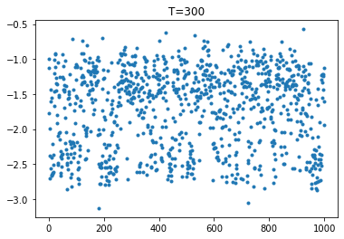

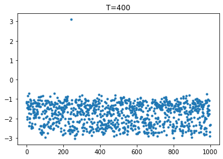

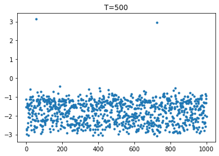

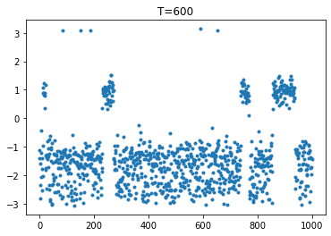

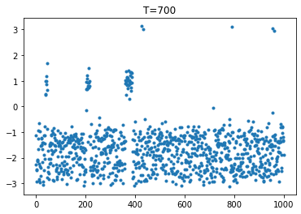

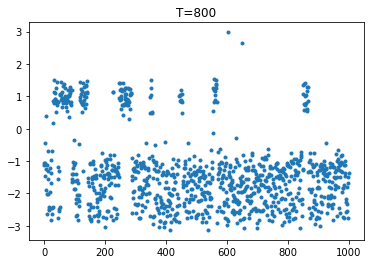

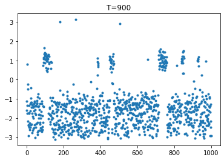

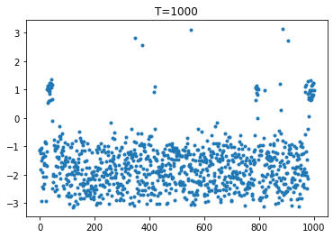

```python
for i in range(len(Ts)):
    plt.title("T={}".format(Ts[i]))
    plt.plot(colvar[i].time,colvar[i].phi,".")
    plt.show()
```

As you can see, the number of transitions to the higher energy state is increasing with temperature. Notice that we have two simultaneous effects:

- The population of state B is increasing as we increase the temperature
- Also the rates (both A->B and B->A are increasign when we increase the temperature